# IA para Científicos Sociales

Sesión 5.3: Laboratorio - Auditoría de sesgo

Danilo Freire

danilofreire@gmail.com

Departament of Data and Decision Sciences  
Emory University

# Laboratorio: Auditoría de sesgo

## Objetivos del laboratorio

**Hoy aprenderemos a:**

1. Instalar y usar fairmodels en R
2. Calcular métricas de equidad por grupo
3. Visualizar disparidades
4. Interpretar resultados de auditoría
5. Discutir trade-offs de equidad

**Caso de estudio:**

Usaremos el dataset German Credit, un clásico en estudios de sesgo algorítmico.

- 1000 solicitudes de crédito
- Variable objetivo: buen/mal pagador
- Atributos sensibles: sexo, edad, estado civil
- Pregunta: ¿el modelo trata igual a hombres y mujeres?

## Preparación del entorno

```r
R> # Instalar paquetes si no están disponibles
R> if (!require("fairmodels")) install.packages("fairmodels")
R> if (!require("DALEX")) install.packages("DALEX")
R> if (!require("ranger")) install.packages("ranger")
R>
R> # Cargar paquetes
R> library(tidyverse)
R> library(tidymodels)
R> library(fairmodels)
R> library(DALEX)
R> library(ranger)
```

fairmodels usa explicadores de DALEX para auditar modelos. Funciona con cualquier modelo de clasificación.

# Parte 1: Datos y modelo

## El dataset German Credit

```r
R> # Cargar datos incluidos en fairmodels
R> data("german", package = "fairmodels")
R>
R> # Explorar estructura
R> glimpse(german)
```

```
Rows: 1,000
Columns: 10
$ Risk             <fct> good, bad, good, good, bad, good, good, good, good, b…
$ Sex              <fct> male, female, male, male, male, male, male, male, mal…
$ Job              <int> 2, 2, 1, 2, 2, 1, 2, 3, 1, 3, 2, 2, 2, 1, 2, 1, 2, 2,…
$ Housing          <fct> own, own, own, free, free, free, own, rent, own, own,…
$ Saving.accounts  <fct> not_known, little, little, little, little, not_known,…
$ Checking.account <fct> little, moderate, not_known, little, little, not_know…
$ Credit.amount    <int> 1169, 5951, 2096, 7882, 4870, 9055, 2835, 6948, 3059,…
$ Duration         <int> 6, 48, 12, 42, 24, 36, 24, 36, 12, 30, 12, 48, 12, 24…
$ Purpose          <fct> radio/TV, radio/TV, education, furniture/equipment, c…
$ Age              <int> 67, 22, 49, 45, 53, 35, 53, 35, 61, 28, 25, 24, 22, 6…
```

**Variables clave:**

- `Risk`: variable objetivo (good/bad)
- `Sex`: atributo protegido
- `Age`: otro atributo sensible
- Variables de crédito: monto, duración, historial

El dataset es de los años 1990 y tiene sesgos históricos conocidos.

## Explorar el atributo protegido

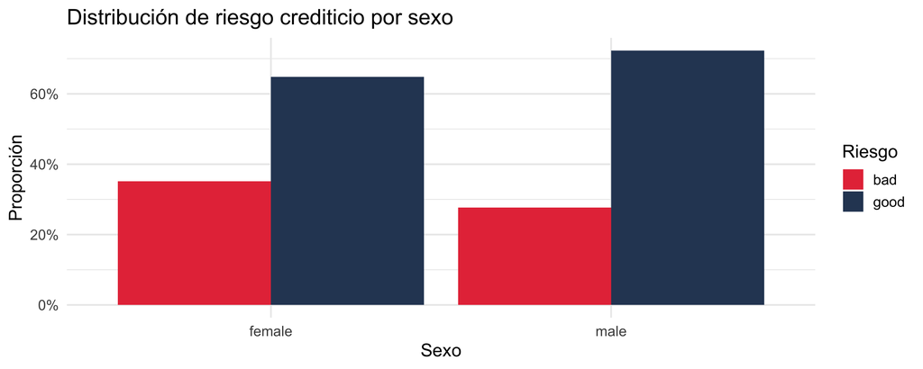

```r
R> # Distribución de Risk por Sex
R> german |>
+   count(Sex, Risk) |>
+   group_by(Sex) |>
+   mutate(prop = n / sum(n)) |>
+   ggplot(aes(x = Sex, y = prop, fill = Risk)) +
+   geom_col(position = "dodge") +
+   scale_fill_manual(values = c("good" = "#2d4563", "bad" = "#e63946")) +
+   scale_y_continuous(labels = scales::percent) +
+   labs(title = "Distribución de riesgo crediticio por sexo",
+        y = "Proporción", x = "Sexo", fill = "Riesgo") +
+   theme_minimal(base_size = 14)
```

Las tasas base son similares entre grupos, lo que facilita la comparación de métricas.

## Preparar los datos

```r
R> # Crear variable binaria para el modelo
R> german <- german |>
+   mutate(
+     Risk_binary = ifelse(Risk == "good", 1, 0),
+     Sex_binary = ifelse(Sex == "male", 1, 0)
+   )
R>
R> # Dividir en train/test
R> set.seed(123)
R> split <- initial_split(german, prop = 0.7, strata = Risk)
R> train_data <- training(split)
R> test_data <- testing(split)
R>
R> cat("Entrenamiento:", nrow(train_data), "filas\n")
```

```
Entrenamiento: 699 filas
```

```r
R> cat("Test:", nrow(test_data), "filas\n")
```

```
Test: 301 filas
```

Usaremos el conjunto de test para evaluar equidad, ya que representa datos no vistos.

## Entrenar un modelo Random Forest

```r
R> # Entrenar Random Forest (sin usar Sex como predictor)
R> rf_model <- ranger(
+   Risk ~ . - Sex - Sex_binary - Risk_binary,
+   data = train_data,
+   probability = TRUE,
+   seed = 123
+ )
R>
R> # Obtener predicciones en test
R> pred_probs <- predict(rf_model, test_data)$predictions[, "good"]
R> pred_class <- ifelse(pred_probs > 0.5, "good", "bad")
R>
R> # Accuracy global
R> accuracy <- mean(pred_class == test_data$Risk)
R> cat("Accuracy global:", round(accuracy, 3), "\n")
```

```
Accuracy global: 0.721
```

El modelo no usa Sex como variable, pero ¿eso garantiza que sea justo?

# Parte 2: Crear el explicador

## ¿Qué es un explicador DALEX?

**DALEX** (Descriptive mAchine Learning EXplanations) es un framework para explicar modelos de ML.

Un explicador es un objeto que envuelve:

- El modelo entrenado
- Los datos de test
- La variable objetivo
- Una función de predicción

fairmodels usa explicadores para calcular métricas de equidad por grupo.

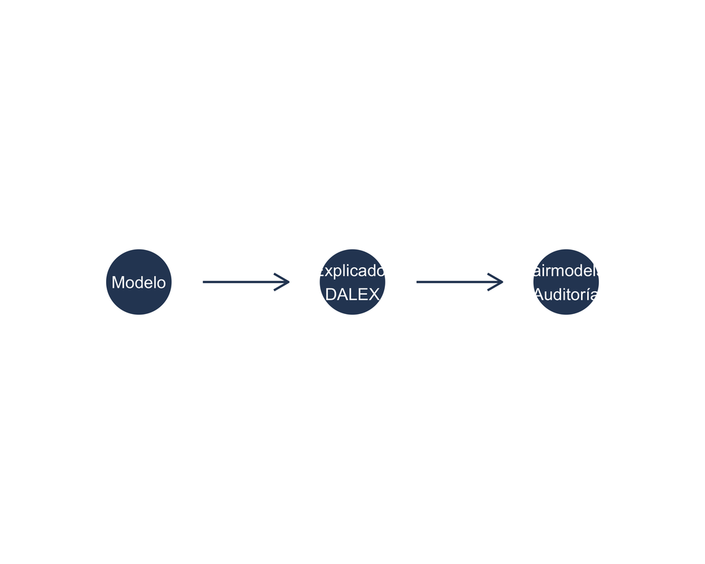

## Crear el explicador

```r
R> # Función de predicción personalizada para ranger
R> predict_function <- function(model, data) {
+   predict(model, data)$predictions[, "good"]
+ }
R>
R> # Crear explicador DALEX
R> explainer <- DALEX::explain(
+   model = rf_model,
+   data = test_data |> select(-Risk, -Risk_binary, -Sex_binary),
+   y = test_data$Risk_binary,
+   predict_function = predict_function,
+   label = "Random Forest",
+   verbose = FALSE
+ )
R>
R> cat("Explicador creado con", nrow(test_data), "observaciones\n")
```

```
Explicador creado con 301 observaciones
```

El explicador está listo para ser auditado por fairmodels.

# Parte 3: Auditoría con fairmodels

## Crear objeto de equidad

```r
R> # Crear objeto fairness con Sex como atributo protegido
R> fobject <- fairness_check(
+   explainer,
+   protected = test_data$Sex,
+   privileged = "male",  # grupo de referencia
+   cutoff = 0.5,
+   verbose = FALSE
+ )
R>
R> # Ver resumen
R> print(fobject)
```

```
Fairness check for models: Random Forest

Random Forest passes 5/5 metrics
Total loss :  0.3484535
```

El grupo privilegiado es el de referencia. Las métricas comparan otros grupos con este.

## Visualizar métricas de equidad

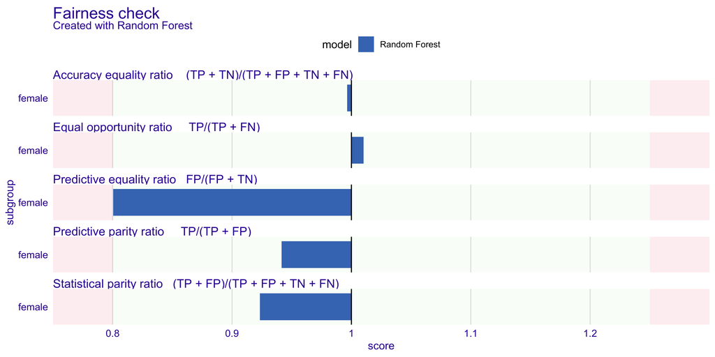

```r
R> # Gráfico de radar de equidad
R> plot(fobject)
```

La zona verde (0.8-1.25) indica equidad aceptable. Fuera de ella hay disparidad.

## Interpretar las métricas

**¿Qué significan las métricas?**

| Métrica | Significado |
| --- | --- |
| TPR | Tasa de verdaderos positivos |
| TNR | Tasa de verdaderos negativos |
| PPV | Valor predictivo positivo |
| NPV | Valor predictivo negativo |
| FPR | Tasa de falsos positivos |
| FNR | Tasa de falsos negativos |
| ACC | Accuracy |
| STP | Statistical parity (tasa de positivos) |

Un ratio de 1.0 significa igualdad perfecta entre grupos.

**Interpretación del gráfico:**

- Valores dentro del área verde (0.8-1.25): equidad aceptable
- Valores fuera: posible sesgo
- Más cerca del centro (1.0) = más equitativo

```r
R> # Extraer métricas numéricas
R> fobject$fairness_check_data |>
+   filter(metric %in% c("TPR", "FPR", "ACC", "STP")) |>
+   select(metric, score) |>
+   mutate(score = round(score, 3))
```

```
[1] metric score
<0 rows> (or 0-length row.names)
```

## Métricas detalladas por grupo

```r
R> # Calcular métricas crudas por grupo
R> group_metrics <- test_data |>
+   mutate(pred = pred_class) |>
+   group_by(Sex) |>
+   summarise(
+     n = n(),
+     accuracy = mean(pred == Risk),
+     tpr = sum(pred == "good" & Risk == "good") / sum(Risk == "good"),
+     fpr = sum(pred == "good" & Risk == "bad") / sum(Risk == "bad"),
+     positive_rate = mean(pred == "good"),
+     .groups = "drop"
+   )
R>
R> group_metrics |>
+   mutate(across(where(is.numeric), ~round(., 3)))
```

```
# A tibble: 2 × 6
  Sex        n accuracy   tpr   fpr positive_rate
  <fct>  <dbl>    <dbl> <dbl> <dbl>         <dbl>
1 female    89    0.719 0.893 0.576         0.775
2 male     212    0.722 0.884 0.719         0.84
```

Estas son las métricas absolutas. fairmodels calcula los ratios entre grupos.

## Comparación visual por grupo

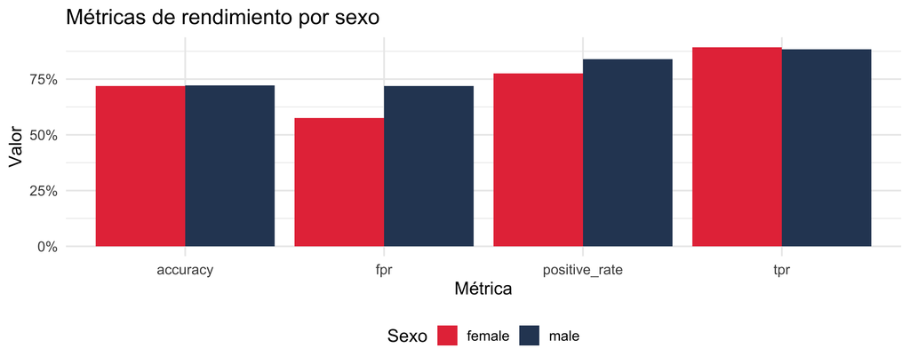

```r
R> # Gráfico de barras de métricas por grupo
R> group_metrics |>
+   pivot_longer(cols = c(accuracy, tpr, fpr, positive_rate),
+                names_to = "metric", values_to = "value") |>
+   ggplot(aes(x = metric, y = value, fill = Sex)) +
+   geom_col(position = "dodge") +
+   scale_fill_manual(values = c("female" = "#e63946", "male" = "#2d4563")) +
+   scale_y_continuous(labels = scales::percent) +
+   labs(title = "Métricas de rendimiento por sexo",
+        y = "Valor", x = "Métrica", fill = "Sexo") +
+   theme_minimal(base_size = 14) +
+   theme(legend.position = "bottom")
```

# Parte 4: Explorar diferentes umbrales

## El efecto del umbral de clasificación

El umbral de 0.5 es arbitrario. Podemos ajustarlo para diferentes objetivos:

- Umbral **más alto** (ej. 0.7): menos falsos positivos, más falsos negativos
- Umbral **más bajo** (ej. 0.3): más falsos positivos, menos falsos negativos

En crédito:

- FP = dar crédito a quien no pagará (pérdida para el banco)
- FN = rechazar a quien pagaría (pérdida de negocio + injusticia)

Los umbrales por grupo son una forma de mitigación post-procesamiento.

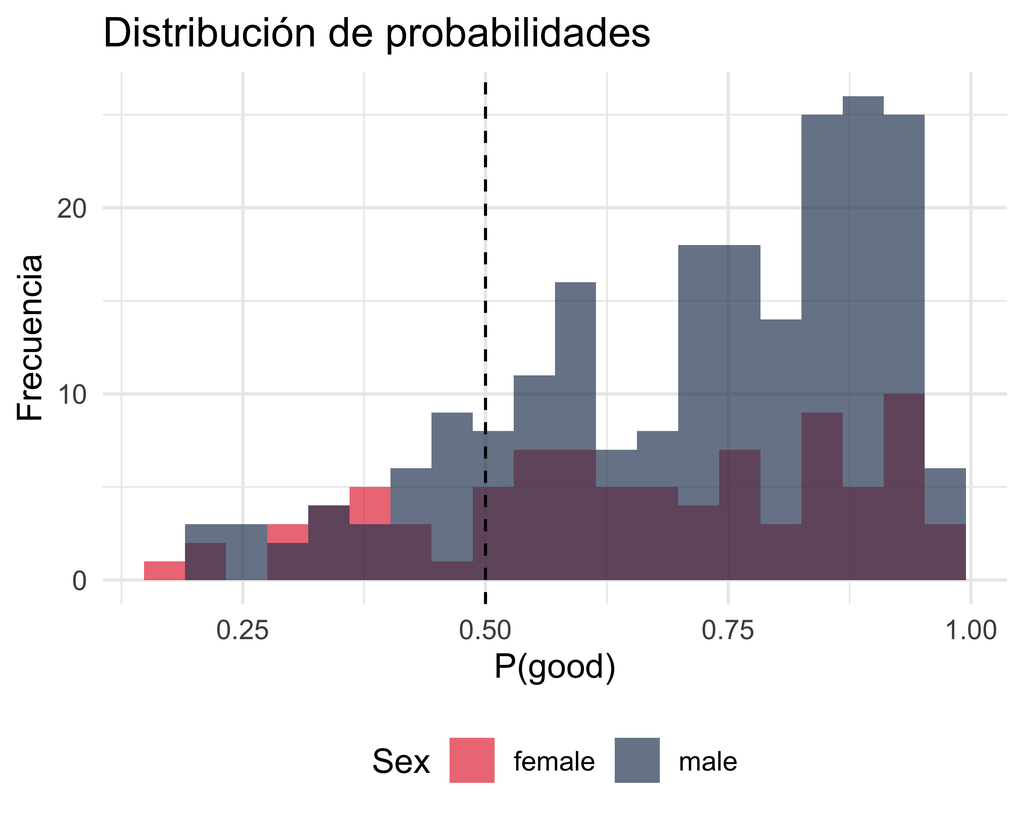

```r
R> # Histograma de probabilidades por grupo
R> test_data |>
+   mutate(prob = pred_probs) |>
+   ggplot(aes(x = prob, fill = Sex)) +
+   geom_histogram(bins = 20, alpha = 0.7, position = "identity") +
+   geom_vline(xintercept = 0.5, linetype = "dashed", color = "black") +
+   scale_fill_manual(values = c("female" = "#e63946", "male" = "#2d4563")) +
+   labs(title = "Distribución de probabilidades",
+        x = "P(good)", y = "Frecuencia") +
+   theme_minimal(base_size = 12) +
+   theme(legend.position = "bottom")
```

## Probar diferentes umbrales

```r
R> # Función para calcular métricas con umbral personalizado
R> calc_metrics_threshold <- function(data, probs, threshold) {
+   pred <- ifelse(probs > threshold, "good", "bad")
+   data |>
+     mutate(pred = pred) |>
+     group_by(Sex) |>
+     summarise(
+       threshold = threshold,
+       accuracy = mean(pred == Risk),
+       tpr = sum(pred == "good" & Risk == "good") / sum(Risk == "good"),
+       fpr = sum(pred == "good" & Risk == "bad") / sum(Risk == "bad"),
+       .groups = "drop"
+     )
+ }
R>
R> # Probar varios umbrales
R> thresholds <- c(0.3, 0.4, 0.5, 0.6, 0.7)
R> results <- map_dfr(thresholds, ~calc_metrics_threshold(test_data, pred_probs, .x))
R>
R> # Mostrar resultados
R> results |>
+   arrange(Sex, threshold) |>
+   mutate(across(where(is.numeric), ~round(., 3)))
```

```
# A tibble: 10 × 5
   Sex    threshold accuracy   tpr   fpr
   <fct>      <dbl>    <dbl> <dbl> <dbl>
 1 female       0.3    0.674 1     0.879
 2 female       0.4    0.708 0.929 0.667
 3 female       0.5    0.719 0.893 0.576
 4 female       0.6    0.719 0.75  0.333
 5 female       0.7    0.652 0.589 0.242
 6 male         0.3    0.741 0.987 0.93
 7 male         0.4    0.745 0.961 0.842
 8 male         0.5    0.722 0.884 0.719
 9 male         0.6    0.684 0.768 0.544
10 male         0.7    0.665 0.697 0.421
```

## Visualizar el trade-off

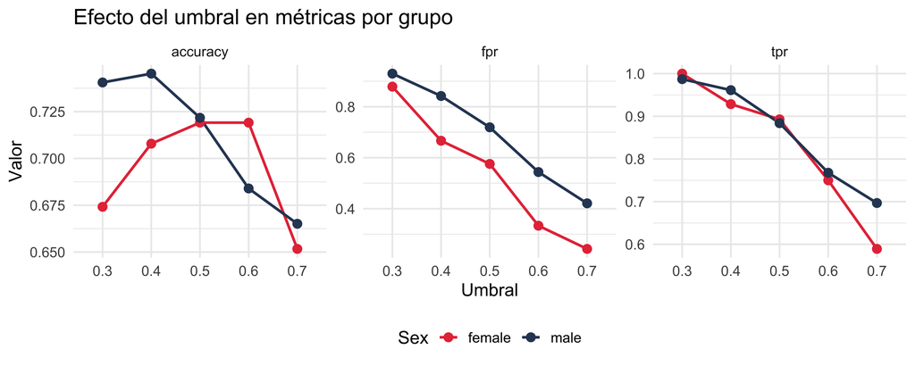

```r
R> results |>
+   pivot_longer(cols = c(accuracy, tpr, fpr), names_to = "metric", values_to = "value") |>
+   ggplot(aes(x = factor(threshold), y = value, color = Sex, group = Sex)) +
+   geom_line(linewidth = 1) +
+   geom_point(size = 3) +
+   facet_wrap(~metric, scales = "free_y") +
+   scale_color_manual(values = c("female" = "#e63946", "male" = "#2d4563")) +
+   labs(title = "Efecto del umbral en métricas por grupo",
+        x = "Umbral", y = "Valor") +
+   theme_minimal(base_size = 14) +
+   theme(legend.position = "bottom")
```

Diferentes umbrales afectan a los grupos de manera diferente.

# Parte 5: Mitigación

## Umbrales diferenciados por grupo

Una estrategia de post-procesamiento es usar umbrales diferentes para cada grupo.

**Objetivo:** igualar la tasa de falsos positivos (FPR).

```r
R> # Encontrar umbral que iguale FPR
R> # Para mujeres, buscar umbral que dé FPR similar a hombres
R> target_fpr <- results |>
+   filter(Sex == "male", threshold == 0.5) |>
+   pull(fpr)
R>
R> cat("FPR objetivo (hombres, umbral 0.5):", round(target_fpr, 3), "\n")
```

```
FPR objetivo (hombres, umbral 0.5): 0.719
```

```r
R> # FPR de mujeres con umbral 0.5
R> female_fpr <- results |>
+   filter(Sex == "female", threshold == 0.5) |>
+   pull(fpr)
R>
R> cat("FPR mujeres (umbral 0.5):", round(female_fpr, 3), "\n")
```

```
FPR mujeres (umbral 0.5): 0.576
```

**Consideraciones éticas:**

- ¿Es justo usar umbrales diferentes por grupo?
- Algunos argumentan que es discriminación inversa
- Otros argumentan que corrige sesgos sistémicos
- Las leyes varían: en EE.UU. está prohibido en empleo; en otros contextos es permitido

La decisión de usar umbrales diferenciados es política, no técnica.

## Comparar modelo original vs. mitigado

```r
R> # Simular mitigación: umbral 0.5 para hombres, 0.45 para mujeres
R> mitigated_pred <- ifelse(
+   test_data$Sex == "male",
+   ifelse(pred_probs > 0.5, "good", "bad"),
+   ifelse(pred_probs > 0.45, "good", "bad")
+ )
R>
R> # Comparar métricas
R> comparison <- test_data |>
+   mutate(
+     pred_original = pred_class,
+     pred_mitigated = mitigated_pred
+   ) |>
+   group_by(Sex) |>
+   summarise(
+     fpr_original = sum(pred_original == "good" & Risk == "bad") / sum(Risk == "bad"),
+     fpr_mitigated = sum(pred_mitigated == "good" & Risk == "bad") / sum(Risk == "bad"),
+     acc_original = mean(pred_original == Risk),
+     acc_mitigated = mean(pred_mitigated == Risk),
+     .groups = "drop"
+   )
R>
R> comparison |> mutate(across(where(is.numeric), ~round(., 3)))
```

```
# A tibble: 2 × 5
  Sex    fpr_original fpr_mitigated acc_original acc_mitigated
  <fct>         <dbl>         <dbl>        <dbl>         <dbl>
1 female        0.576         0.636        0.719         0.697
2 male          0.719         0.719        0.722         0.722
```

La mitigación reduce la disparidad en FPR, pero puede afectar otras métricas.

# Parte 6: Discusión grupal

## Actividad: Debate sobre trade-offs

**Escenario:**

Son consultores de un banco uruguayo que quiere implementar un modelo de scoring crediticio.

El banco les pide una recomendación.

**Preguntas para discutir (15 min):**

1. ¿Deberían usar umbrales diferenciados por sexo?
2. Si lo hacen, ¿es discriminación positiva o simplemente corrección de sesgo?
3. ¿Qué métrica de equidad priorizarían y por qué?
4. ¿Cómo comunicarían la decisión a los clientes?
5. ¿Qué información adicional necesitarían para decidir?

**Divídanse en grupos de 4. Cada grupo presentará su recomendación (3 min).**

## Preguntas guía para la discusión

1. **Contexto histórico:** ¿las mujeres han tenido históricamente menos acceso al crédito en Uruguay?
2. **Causa de la disparidad:** ¿el FPR más alto se debe al modelo o a diferencias en los datos?
3. **Consecuencias:** ¿qué pasa si una mujer buena pagadora es rechazada? ¿Y si un hombre mal pagador es aprobado?
4. **Alternativas:** además de ajustar umbrales, ¿hay otras formas de abordar la disparidad?
5. **Transparencia:** ¿los clientes deberían saber que se usan umbrales diferentes?
6. **Legalidad:** ¿la ley uruguaya permite trato diferenciado por sexo en decisiones de crédito?

# Parte 7: Ejercicio individual

## Auditar con otra variable protegida

**Ejercicio:**

Repitan la auditoría usando edad como variable protegida.

1. Crear grupos de edad (ej. jóvenes < 30, adultos 30-50, mayores > 50)
2. Calcular métricas de equidad para cada grupo
3. Visualizar disparidades
4. Identificar qué grupo es más perjudicado

**Código inicial:**

```r
R> # Crear grupos de edad
R> test_data <- test_data |>
+   mutate(
+     Age_group = case_when(
+       Age < 30 ~ "joven",
+       Age < 50 ~ "adulto",
+       TRUE ~ "mayor"
+     )
+   )
R>
R> # Crear nuevo objeto fairness
R> fobject_age <- fairness_check(
+   explainer,
+   protected = test_data$Age_group,
+   privileged = "adulto",
+   cutoff = 0.5,
+   verbose = FALSE
+ )
R>
R> # Visualizar
R> plot(fobject_age)
```

**Preguntas a responder:**

1. ¿Qué grupo de edad tiene peor rendimiento?
2. ¿En qué métricas hay mayor disparidad?
3. ¿Tiene sentido que adultos sean el grupo privilegiado?
4. ¿Cómo se compara el sesgo por edad con el sesgo por sexo?

**Tiempo:** 15 minutos

Trabajen individualmente o en parejas. Pueden consultar la documentación de fairmodels.

## Solución del ejercicio

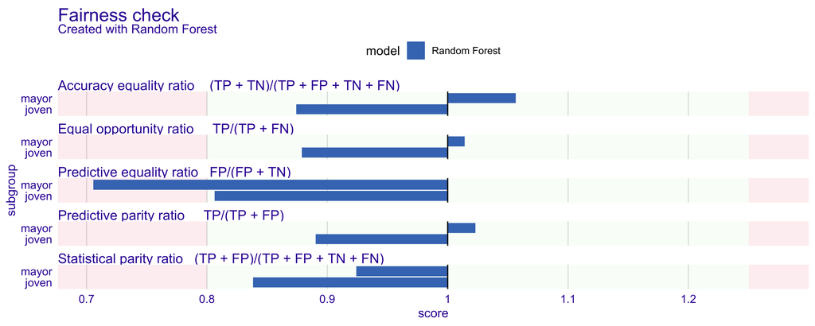

```r
R> # Crear grupos de edad
R> test_data <- test_data |>
+   mutate(
+     Age_group = case_when(
+       Age < 30 ~ "joven",
+       Age < 50 ~ "adulto",
+       TRUE ~ "mayor"
+     )
+   )
R>
R> # Crear objeto fairness por edad
R> fobject_age <- fairness_check(
+   explainer,
+   protected = test_data$Age_group,
+   privileged = "adulto",
+   cutoff = 0.5,
+   verbose = FALSE
+ )
R>
R> # Visualizar
R> plot(fobject_age)
```

## Resumen del laboratorio

**Lo que aprendimos:**

- Usar fairmodels para auditar modelos
- Calcular métricas de equidad con fairness_check()
- Visualizar disparidades con plot()
- El efecto del umbral en la equidad
- Mitigación con umbrales diferenciados

**Ideas clave:**

- Un modelo sin variables sensibles puede seguir siendo sesgado
- Diferentes métricas capturan diferentes nociones de equidad
- La mitigación implica trade-offs
- Las decisiones de equidad son políticas, no solo técnicas
- La auditoría debe ser parte del ciclo de vida del modelo

En la próxima sesión: mini-propuestas de investigación y cierre del curso.

# Nos vemos en la sesión 5.4